# Tutorial, Week 1: Web data collection 1

SECU0050

B Kleinberg

16 Jan 2020

# SOLUTIONS

Aims of this tutorial:

- building your first small programm to access web data using an API access point
- using web data to examine temporal patterns
- accessing the HTML structure of web pages

*Note: this tutorial assumes that you have [obtained an API key from the Guardian](https://open-platform.theguardian.com/access/) as per the email we sent a few days ago.*

## Task 1: Building an access pipeline to the Guardian

1. Install and load the GuardianR package
2. Build your first query

Search for articles in The Guardian around a topic of your choice (choose one that gives you more than 20 results for a month). Note that exact keyword searches need to be defined slighlty differently (see p2 on https://cran.r-project.org/web/packages/GuardianR/GuardianR.pdf).

```r
#Replace your info in the placeholder below and uncomment the code (remove the #)
get_guardian("Cryptocurrency+AND+Trump",
             from.date="2019-08-01",
             to.date="2019-08-30",
             api.key="236e7903-4e89-42df-9348-439cc792...")
```

Note that running the above does not store the results internally as an object but merely prints the output to the console. To fix this, store the query as a variable called `my_query_1`

```r
my_query_1 = get_guardian("Cryptocurrency+AND+Trump",
                    from.date="2019-08-01",
                    to.date="2019-08-30",
                    api.key="236e7903-4e89-42df-9348-439cc792...")
```

3. Run multiple search queries for 6 months

Similar to most APIs, the Guardian has restrictions as to how much data you can retrieve with one query. Typically, one API call is limited to a month. To circumvent this, run six different queries, each containing a date range of one month using your search query above.

Name these queries `my_query_1_july`, `my_query_1_aug`, `my_query_1_sept`, …, `my_query_1_dec` for the last six months of the year 2019.

```r
#OPTION 1: per month separately
my_query_1_july = get_guardian("%22bushfire%22",
                             from.date="2019-07-01",
                             to.date="2019-07-31",
                             api.key="APIKEYHERE")
my_query_1_aug = get_guardian("%22bushfire%22",
                             from.date="2019-08-01",
                             to.date="2019-08-31",
                             api.key="APIKEYHERE")
my_query_1_sept = get_guardian("%22bushfire%22",
                             from.date="2019-09-01",
                             to.date="2019-09-30",
                             api.key="APIKEYHERE")
my_query_1_oct = get_guardian("%22bushfire%22",
                             from.date="2019-10-01",
                             to.date="2019-10-31",
                             api.key="APIKEYHERE")
my_query_1_nov = get_guardian("%22bushfire%22",
                             from.date="2019-11-01",
                             to.date="2019-11-30",
                             api.key="APIKEYHERE")
my_query_1_dec = get_guardian("%22bushfire%22",
                             from.date="2019-12-01",
                             to.date="2019-12-31",
                             api.key="APIKEYHERE")

#OPTION 2: for loop (note: the search term is different in this example)

months <- c(07,08,09,10,11,12)
names(months) <- c("jul","aug","sep","oct","nov","dec")

for (i in 1:length(months)) {
# add the name of the month to the end of the query name
  name <- paste("my_query_1_", names(months)[i], sep="")

# assign the value of the API call to the new var name we created
# this does not cleanly handle dates at the moment: it assumes the month always ends on the 30th

  assign(name,
         get_guardian("Cryptocurrency",
             from.date=sprintf("2019-%d-01",months[i]),
             to.date=sprintf("2019-%d-30",months[i]),
             api.key="236e7903-4e89-42df-9348-439cc792a4fd")
  )
}
```

Now we want to join these six variables - each holding one month worth of search query results - into one object. To do this, run the following command:

```r
#Insert all six variable created above in the list argument and uncomment and run the code.

guardian_query_six_months = do.call(rbind, list(my_query_1_july
                                                , my_query_1_aug
                                                , my_query_1_sept
                                                , my_query_1_oct
                                                , my_query_1_nov
                                                , my_query_1_dec
                                                ))
```

Now you have one object with all search results for the months July - Dec 2019 for your search query.

## Task 2: Identifying patterns in retrieved web data

We now use the object you created above to have a closer look at the data.

1. Examine the data for outliers in the article length

Now plot the word count using the `plot` command to look for outliers.

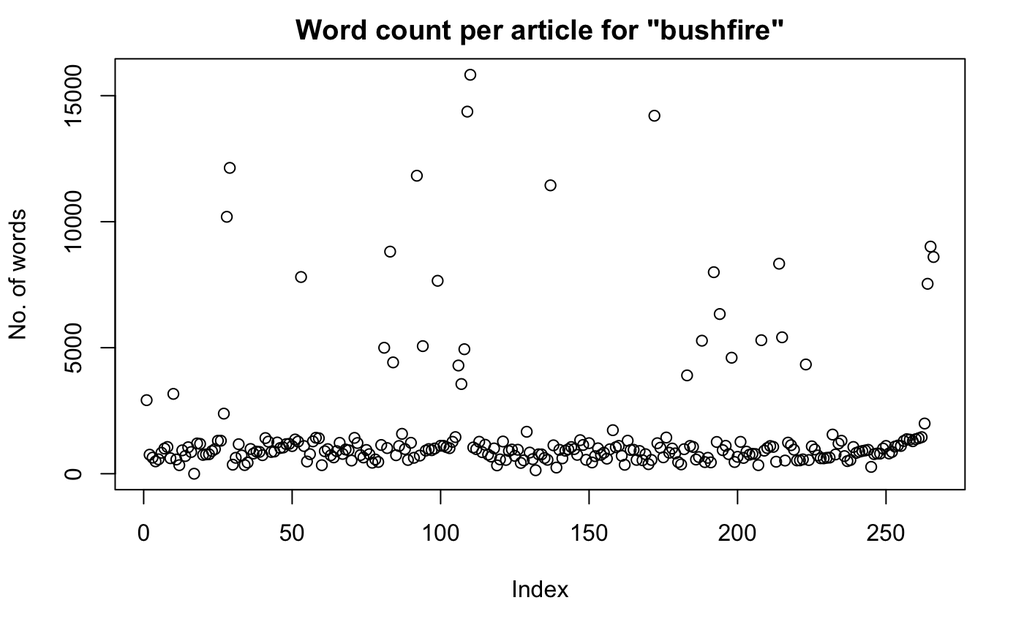

Aside from a visual inspection, we always want to have numerical certainty. Use the `table` command to assess how many word count values are larger than the mean plus 3 standard deviations.

```r
mean3sd = mean(guardian_query_six_months$word_count_converted) + 3*sd(guardian_query_six_months$word_count_converted)
table(guardian_query_six_months$word_count_converted > mean3sd)
```

```
FALSE  TRUE
  258     8
```

2. Looking for the temporal development of article length

You can now sort the dataframe by date ([hint](https://www.statmethods.net/management/sorting.html)) and plot the date to see how the article length changed over time:

For plotting, use the base R plot function and specify the x and y-axes separately:

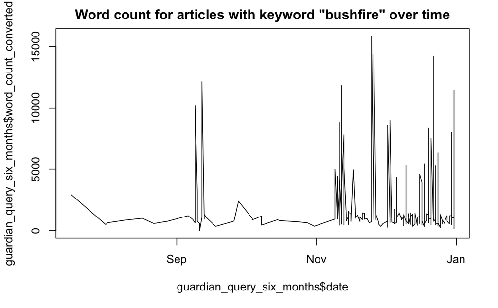

**Note how changing the `type` argument affects the plot**

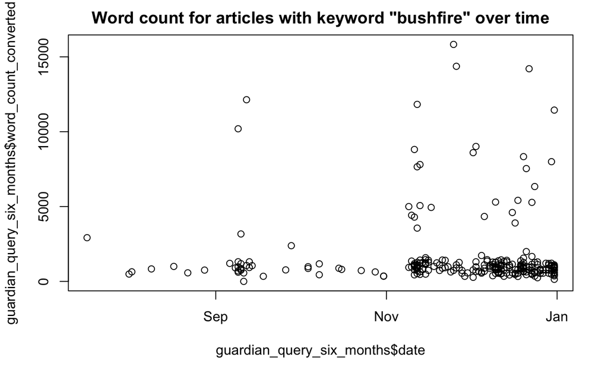

- create a month variable based on the date variable ([hint](https://stackoverflow.com/questions/22603847/how-to-extract-month-from-date-in-r))
- aggregate the data by month ([hint](https://www.rdocumentation.org/packages/stats/versions/3.6.2/topics/aggregate))

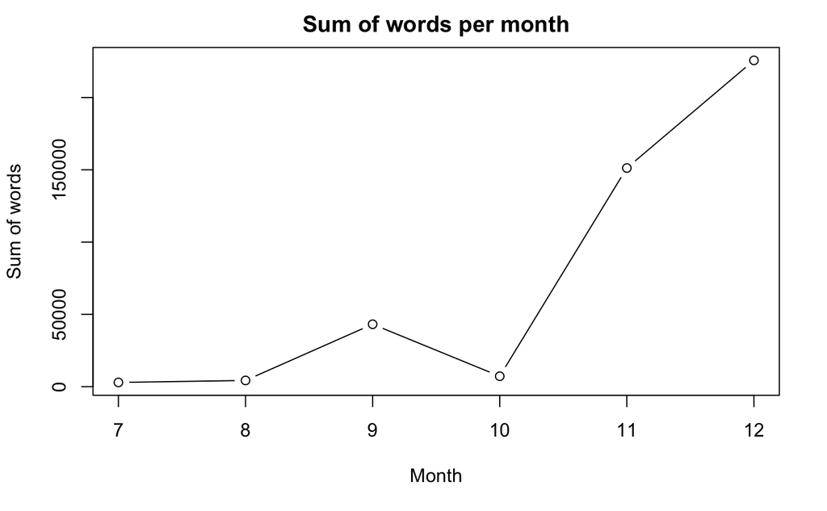

## Task 3: Accessing the HTML structure using your browser

To start with proper webscraping, you need to understand the basic idea of HTML and how it is used to display webpages.

Open your browswer (e.g. Firefox, Chrome, Safari) and go to the website for missing people in the UK: https://www.missingpeople.org.uk/help-us-find.html.

Use the technique discussed in the lecture to inspect the HTML structure. Try to identify how the brief previews are structured that lead you to the details pages of each missing person.

What do you notice?

**Points to note:**

- each preview photo is contained in a div element
- that div element has the attribute: `class="teaser-item"`
- if we can extract each div with that class, we can access each of the previews

## Task 4: Retrieving the HTML structure of a webpage using R

We can do the manual steps from above in a programmatic manner as well. We will do that in detail next week. For now, let’s start with the basics and just obtain the core HTML structure using the `rvest` package.

Install the `rvest` package first if you haven’t done so.

```r
target %>%
  html_nodes('.teaser-item')
```

```
{xml_nodeset (30)}
 [1] <div class="teaser-item">\n\t\n\t<div class="teaser-item-inner">\n\t<a href="/h ...
 [2] <div class="teaser-item">\n\t\n\t<div class="teaser-item-inner">\n\t<a href="/h ...
 [3] <div class="teaser-item">\n\t\n\t<div class="teaser-item-inner">\n\t<a href="/h ...
 [4] <div class="teaser-item">\n\t\n\t<div class="teaser-item-inner">\n\t<a href="/h ...
 [5] <div class="teaser-item">\n\t\n\t<div class="teaser-item-inner">\n\t<a href="/h ...
 [6] <div class="teaser-item">\n\t\n\t<div class="teaser-item-inner">\n\t<a href="/h ...
 [7] <div class="teaser-item">\n\t\n\t<div class="teaser-item-inner">\n\t<a href="/h ...
 [8] <div class="teaser-item">\n\t\n\t<div class="teaser-item-inner">\n\t<a href="/h ...
 [9] <div class="teaser-item">\n\t\n\t<div class="teaser-item-inner">\n\t<a href="/h ...
[10] <div class="teaser-item">\n\t\n\t<div class="teaser-item-inner">\n\t<a href="/h ...
[11] <div class="teaser-item">\n\t\n\t<div class="teaser-item-inner">\n\t<a href="/h ...
[12] <div class="teaser-item">\n\t\n\t<div class="teaser-item-inner">\n\t<a href="/h ...
[13] <div class="teaser-item">\n\t\n\t<div class="teaser-item-inner">\n\t<a href="/h ...
[14] <div class="teaser-item">\n\t\n\t<div class="teaser-item-inner">\n\t<a href="/h ...
[15] <div class="teaser-item">\n\t\n\t<div class="teaser-item-inner">\n\t<a href="/h ...
[16] <div class="teaser-item">\n\t\n\t<div class="teaser-item-inner">\n\t<a href="/h ...
[17] <div class="teaser-item">\n\t\n\t<div class="teaser-item-inner">\n\t<a href="/h ...
[18] <div class="teaser-item">\n\t\n\t<div class="teaser-item-inner">\n\t<a href="/h ...
[19] <div class="teaser-item">\n\t\n\t<div class="teaser-item-inner">\n\t<a href="/h ...
[20] <div class="teaser-item">\n\t\n\t<div class="teaser-item-inner">\n\t<a href="/h ...
...
```

*Hint: look for the class of the div that contains each ‘teaser’*

## Homework

### Part 1: Accessing the preprint server arXiv

Use the `aRxiv` package to build an access pipeline to the academic paper repository Arxiv.

Read the installation guideline at https://ropensci.org/tutorials/arxiv_tutorial/ and - using the tutorial prepared there - to answer the following questions:

- How many papers contain the wild card term “crim” in their title?
- What is the title of the most recently submitted paper on arxiv in all categories?
- Which author(s) submitted the first paper of 2020 in the computation and language category?

### Part 2: Replicate code to access the Twitter API

There are many APIs that allow you to use web data in a structured manner. Among the most frequently used (because most easily obtainable) data sources is Twitter. R offers an access point to Twitter as well and provides you with detailed functionality to retrieve Twitter data.

Read through the documents of the `rtweet` package below:

- [Package docs as pdf](https://cran.r-project.org/web/packages/rtweet/rtweet.pdf)
- [Online documentation](https://www.rdocumentation.org/packages/rtweet/versions/0.6.9)

Now have a look at the package website https://rtweet.info/

Once you have done the above, try to replicate the example provided at https://rtweet.info/articles/intro.html. Once you have the code running, attempt to define some search queries of your own. You can skip the visualisations of you do not yet feel comfortable running this code.

*Important:* You need a Twitter account for this part of the homework. If you do not have one or do not wish to create one or use your account, you can skip this part.

*Caution:* Remember that an API typically allows for two-way access. You can retrieve data but you can also send data. This means that you can use the R package to Tweet under your account.

### Part 3: Starting with your project

Have a close look at the project assessment for this module. While many aspects (esp. the natural language processing part and the machine learning) will not be clear at this point, it is advisable that you start to map out a few ideas at this stage already. This can include ideas on data sources and the overall context of your project. These ideas can then be revisited throughout the module and will make it easy for you to run your project.

Prepare some ideas. We will ask a few students next week to talk about their initial ideas.

### Part 4: Preparation for next week

Please ensure that you have installed and can load the following R packages:

- RSelenium
- rvest